# MTH 643: Problem Set 3

Jade Muyambo

2025-03-04

```r
library(quantmod)
library(fGarch)
library(dplyr)
library(MASS)
```

```r
library(ggplot2)
```

Question 1

```r
getSymbols(c("BAC", "JPM"), src = "yahoo", from = as.Date("2020-01-01"), to = as.Date("2025-01-01"))
```

```
## [1] "BAC" "JPM"
```

```r
BAC_adjusted <- BAC[, "BAC.Adjusted"]
JPM_adjusted <- JPM[, "JPM.Adjusted"]
BAC_log_returns <- diff(log(BAC_adjusted))
JPM_log_returns <- diff(log(JPM_adjusted))
logR <- data.frame(BAC = BAC_log_returns, JPM = JPM_log_returns)
logR <- na.omit(logR)
head(logR)
```

```
##            BAC.Adjusted JPM.Adjusted
## 2020-01-03 -0.020981859 -0.013284148
## 2020-01-06 -0.001433607 -0.000795561
## 2020-01-07 -0.006621395 -0.017146607
## 2020-01-08  0.010058903  0.007770544
## 2020-01-09  0.001714148  0.003644639
## 2020-01-10 -0.008313057 -0.010018029
```

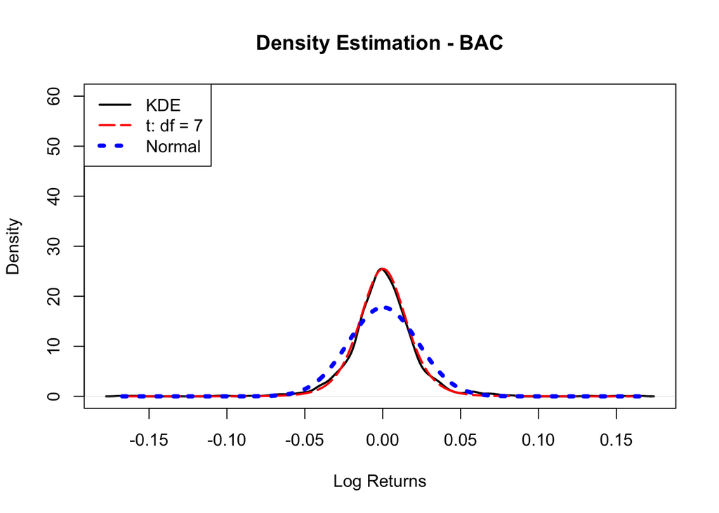

```r
df = 7
mad_BAC = mad(logR$BAC, constant = sqrt(df / (df - 2)) / qt(0.75, df))
mad_JPM = mad(logR$JPM, constant = sqrt(df / (df - 2)) / qt(0.75, df))
x = seq(min(logR), max(logR), length.out = 1000)
plot(density(logR$BAC), lwd = 2, ylim = c(0, 60), main = "Density Estimation - BAC",
     xlab = "Log Returns", ylab = "Density", col = "black")
lines(x, dstd(x, mean = mean(logR$BAC), sd = mad_BAC, nu = df), lty = 5, lwd = 2, col = "red")
lines(x, dnorm(x, mean = mean(logR$BAC), sd = sd(logR$BAC)), lty = 3, lwd = 4, col = "blue")
legend("topleft", c("KDE", paste("t: df =", df), "Normal"),
       lwd = c(2, 2, 4), lty = c(1, 5, 3), col = c("black", "red", "blue"))
```

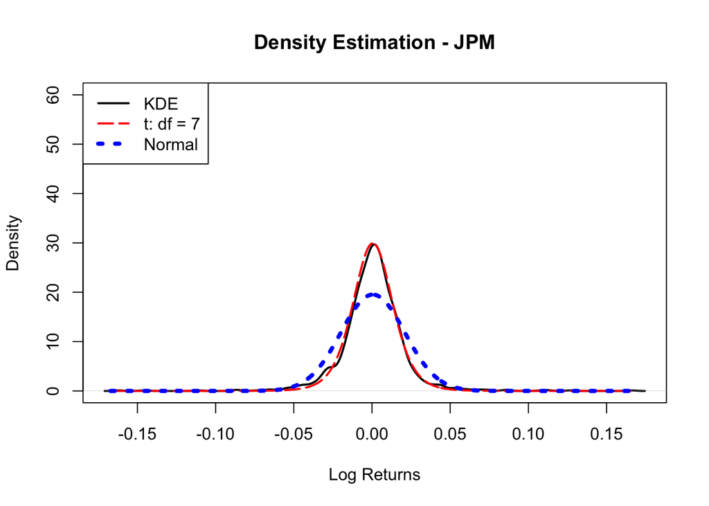

```r
plot(density(logR$JPM), lwd = 2, ylim = c(0, 60), main = "Density Estimation - JPM",
     xlab = "Log Returns", ylab = "Density", col = "black")
lines(x, dstd(x, mean = mean(logR$JPM), sd = mad_JPM, nu = df), lty = 5, lwd = 2, col = "red")
lines(x, dnorm(x, mean = mean(logR$JPM), sd = sd(logR$JPM)), lty = 3, lwd = 4, col = "blue")
legend("topleft", c("KDE", paste("t: df =", df), "Normal"),
       lwd = c(2, 2, 4), lty = c(1, 5, 3), col = c("black", "red", "blue"))
```

Question 2

```r
getSymbols(c("BAC", "JPM"), src = "yahoo", from = as.Date("2020-01-01"), to = as.Date("2025-01-01"))
```

```
## [1] "BAC" "JPM"
```

```r
BAC_data <- data.frame(Date = index(BAC), Adjusted = as.numeric(BAC$BAC.Adjusted), Volume = as.numeric(BAC$BAC.Volume))
JPM_data <- data.frame(Date = index(JPM), Adjusted = as.numeric(JPM$JPM.Adjusted), Volume = as.numeric(JPM$JPM.Volume))
BAC_data <- BAC_data %>%
  mutate(Log_Return = c(NA, diff(log(Adjusted))),
         Lag1 = lag(Log_Return, 1),
         Lag2 = lag(Log_Return, 2),
         Direction = ifelse(Log_Return > 0, 1, 0)) %>%
  na.omit()

JPM_data <- JPM_data %>%
  mutate(Log_Return = c(NA, diff(log(Adjusted))),
         Lag1 = lag(Log_Return, 1),
         Lag2 = lag(Log_Return, 2),
         Direction = ifelse(Log_Return > 0, 1, 0)) %>%
  na.omit()

BAC_glm <- glm(Direction ~ Lag1 + Lag2 + Volume, data = BAC_data, family = binomial)
JPM_glm <- glm(Direction ~ Lag1 + Lag2 + Volume, data = JPM_data, family = binomial)
summary(BAC_glm)
```

```
##
## Call:
## glm(formula = Direction ~ Lag1 + Lag2 + Volume, family = binomial,
##     data = BAC_data)
##
## Coefficients:
##               Estimate Std. Error z value Pr(>|z|)
## (Intercept)  1.036e-01  1.372e-01   0.755    0.450
## Lag1        -1.124e+00  2.541e+00  -0.442    0.658
## Lag2         1.141e+00  2.550e+00   0.447    0.655
## Volume      -1.982e-09  2.506e-09  -0.791    0.429
##
## (Dispersion parameter for binomial family taken to be 1)
##
##     Null deviance: 1739.8  on 1254  degrees of freedom
## Residual deviance: 1738.7  on 1251  degrees of freedom
## AIC: 1746.7
##
## Number of Fisher Scoring iterations: 3
```

```r
summary(JPM_glm)
```

```
##
## Call:
## glm(formula = Direction ~ Lag1 + Lag2 + Volume, family = binomial,
##     data = JPM_data)
##
## Coefficients:
##               Estimate Std. Error z value Pr(>|z|)
## (Intercept)  3.670e-01  1.217e-01   3.016  0.00256 **
## Lag1        -3.709e+00  2.874e+00  -1.290  0.19689
## Lag2         4.392e+00  2.891e+00   1.519  0.12866
## Volume      -2.134e-08  8.219e-09  -2.596  0.00943 **
## ---
## Signif. codes:  0 '***' 0.001 '**' 0.01 '*' 0.05 '.' 0.1 ' ' 1
##
## (Dispersion parameter for binomial family taken to be 1)
##
##     Null deviance: 1737.4  on 1254  degrees of freedom
## Residual deviance: 1725.7  on 1251  degrees of freedom
## AIC: 1733.7
##
## Number of Fisher Scoring iterations: 4
```

```r
BAC_probs <- predict(BAC_glm, type = "response")
JPM_probs <- predict(JPM_glm, type = "response")
BAC_pred <- ifelse(BAC_probs > 0.5, 1, 0)
JPM_pred <- ifelse(JPM_probs > 0.5, 1, 0)
BAC_accuracy <- mean(BAC_pred == BAC_data$Direction)
JPM_accuracy <- mean(JPM_pred == JPM_data$Direction)
print(paste("BAC Model Accuracy:", round(BAC_accuracy * 100, 2), "%"))
```

```
## [1] "BAC Model Accuracy: 49.4 %"
```

```r
print(paste("JPM Model Accuracy:", round(JPM_accuracy * 100, 2), "%"))
```

```
## [1] "JPM Model Accuracy: 53.31 %"
```

These results indicate that using simple logistic regression with past returns and volume does not provide a reliable way to predict future stock price movements for BAC and JPM. The low accuracy suggests that stock prices are influenced by many other factors beyond recent price changes and trading volume, such as market trends, economic indicators, and investor sentiment. Additionally, the fact that the models performed close to 50% accuracy implies that stock price movements might be largely random or require more sophisticated features (such as technical indicators or external financial news) for better predictions.

Question 3

```r
BAC_lda <- lda(Direction ~ Lag1 + Lag2 + Volume, data = BAC_data)
JPM_lda <- lda(Direction ~ Lag1 + Lag2 + Volume, data = JPM_data)
print(BAC_lda)
```

```
## Call:
## lda(Direction ~ Lag1 + Lag2 + Volume, data = BAC_data)
##
## Prior probabilities of groups:
##         0         1
## 0.4988048 0.5011952
##
## Group means:
##           Lag1          Lag2   Volume
## 0 5.480346e-04 -9.756349e-05 50396118
## 1 1.737189e-05  6.420266e-04 49339687
##
## Coefficients of linear discriminants:
##                  LD1
## Lag1   -1.883427e+01
## Lag2    1.912311e+01
## Volume -3.328351e-08
```

```r
print(JPM_lda)
```

```
## Call:
## lda(Direction ~ Lag1 + Lag2 + Volume, data = JPM_data)
##
## Prior probabilities of groups:
##         0         1
## 0.4780876 0.5219124
##
## Group means:
##            Lag1          Lag2   Volume
## 0  0.0013429235 -0.0006066993 13686372
## 1 -0.0001825136  0.0015948757 12620634
##
## Coefficients of linear discriminants:
##                  LD1
## Lag1   -1.846873e+01
## Lag2    2.192584e+01
## Volume -1.090571e-07
```

```r
BAC_pred_lda <- predict(BAC_lda)$class
JPM_pred_lda <- predict(JPM_lda)$class
BAC_accuracy_lda <- mean(BAC_pred_lda == BAC_data$Direction)
JPM_accuracy_lda <- mean(JPM_pred_lda == JPM_data$Direction)
print(paste("BAC LDA Model Accuracy:", round(BAC_accuracy_lda * 100, 2), "%"))
```

```
## [1] "BAC LDA Model Accuracy: 49.4 %"
```

```r
print(paste("JPM LDA Model Accuracy:", round(JPM_accuracy_lda * 100, 2), "%"))
```

```
## [1] "JPM LDA Model Accuracy: 53.39 %"
```

The Linear Discriminant Analysis (LDA) model was used to predict whether the stock price would go up or down based on the previous two days’ log returns (Lag1, Lag2) and trading volume (Volume). For BAC, the LDA model produced an accuracy of 49.4%, which is nearly the same as random guessing (50%). Similarly, for JPM, the accuracy was 53.39%, which is only slightly better than chance. These results indicate that the past two days’ returns, and volume do not provide strong predictive power for future stock movements. The coefficients of the linear discriminants show that Lag1 and Lag2 have the most influence on the classification, but their impact does not significantly improve prediction accuracy.

Comparing LDA to logistic regression, the performance of both models is very similar. The JPM LDA model performed slightly better than its logistic regression counterpart, but not by a large margin, suggesting that stock price movements are highly random and difficult to classify using only past returns and volume. The prior probabilities in the LDA results confirm that the stock movements are almost evenly split between “Up” and “Down” days, reinforcing that the market follows a nearly unpredictable pattern. To improve prediction accuracy, more complex features such as momentum indicators, external financial news, or market sentiment analysis may be needed.

Question 4

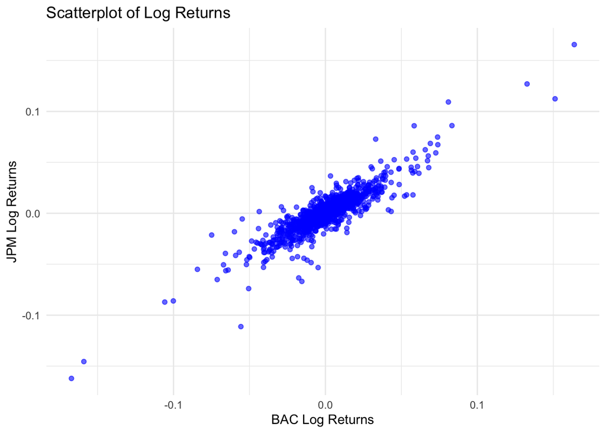

```r
ggplot(data = data.frame(x = BAC_data$Log_Return, y = JPM_data$Log_Return), aes(x = x, y = y)) +
  geom_point(alpha = 0.6, color = "blue") +
  labs(title = "Scatterplot of Log Returns",
       x = "BAC Log Returns",
       y = "JPM Log Returns") +
  theme_minimal()
```

The scatterplot shows the relationship between the log returns of BAC (Bank of America) and JPM (JPMorgan Chase & Co.) stocks. The points form a tight cluster along a diagonal line, suggesting a strong positive correlation. When BAC’s returns increase, JPM’s returns tend to increase as well, and vice versa. The density of points in the center indicates that most daily returns are small, meaning both stocks typically experience minor fluctuations rather than extreme changes. There are a few outliers, where some points are farther from the main cluster, which could represent unusual trading days with sudden price jumps or drops. Overall, the scatterplot suggests that BAC and JPM move similarly in the market, likely due to their exposure to similar economic and financial conditions.